# A Quantitative Approach to the Status of the Magnetic Media Crisis: From Hoping to Knowing

Jared Nistler

Sarah Nguyen

Darach Miller

Abstract

# Introduction

During the twentieth century, vast amounts of valuable historical and cultural information were recorded on magnetic tape—a recording medium made of “a thin layer capable of recording a magnetic signal supported by a thicker film backing.” These items, known as “magnetic media,” include objects such as VHS, compact cassette, U-matic, 7-inch reels, and more. While cost-effective and accessible at the time, magnetic media has a limited archival lifespan. At the end of its life, the magnetic coating can begin to degrade and decay, especially when stored in suboptimal conditions, endangering the survival of its contents. Additionally, as these formats age, the availability of playback equipment and experts who can repair and maintain that equipment decrease with every year until they are completely obsolete. In a race against the clock, archival institutions are limited both by funds and time as they attempt to preserve valuable media before it degrades into unreadability. These institutions must carefully schedule and prioritize their digitization efforts, taking into account their mission, the contents of their collections, and the type of material which they accession.

It is widely recognized that archivists are facing a “magnetic media crisis,” but unfortunately, any existing quantitative literature on the issue is sorely lacking. Few attempts have been made to systematically assess the state of audiovisual (A/V) magnetic media collections. That quantitative gap is the focus of this project.

This study surveyed academic libraries and archives in order to gather quantitative data on collection size, format composition, and digitization percentage to evaluate the current state of magnetic media collections. Several A/V archivists currently working in the field were also interviewed to gather a qualitative understanding of their collection management strategies and digitization workflows. Our results will illustrate the scope of the issue, helping archival institutions to better advocate for their preservation needs.

# Background: What is Magnetic Media?

Unfortunately, magnetic tape has several inherent vices that have led to a preservation crisis. Mike Casey calls the magnetic media crisis a “perfect storm,” because the collections are growing in size and importance (through acquisitions, donations, and requests) as they are simultaneously fading into obsolescence. The problems that Casey identifies for archival institutions regarding magnetic media include “large numbers, obsolescence, degradation, high research value, and short time window.” The first challenge archivists face is identifying just how much of the once-ubiquitous material exists. The next challenge is its limited lifespan. As magnetic media ages, the top coat and backing absorb moisture, causing the tape to become sticky and fall apart. This condition is known as “sticky-shed syndrome” and can render the item unplayable, as well as cause damage to playback equipment.

Limited lifespan and large numbers make the magnetic media crisis daunting enough. However, not only are the old tapes degrading beyond readability, but the machines, hardware, and software needed to digitize valuable content are harder to come by and face obsolescence themselves. Furthermore, as the tools used to work with obsolete magnetic media slowly fade into memory so do the skills and institutional knowledge needed to operate legacy platforms.

In some cases, the content on magnetic tapes represents the clearest picture of an event, person, or place in history, capturing speech patterns, rhythms, and even coughs as they sputtered out in real time. That information’s potential loss poses a serious threat to the historical record, if not addressed immediately.

# Literature Review: Admitting There’s a Problem

The literature on magnetic media preservation is extensive but suffers from significant gaps—most notably a lack of quantitative data about the scope and scale of the preservation crisis. It is widely known that magnetic tape degrades over time and that digitizing the information stored on tape, in preparation to preserve, is difficult and expensive. As a result, several institutions have begun to develop and publish preservation plans. However, there appears to be no general survey of how much magnetic media exists in academic libraries and what state the collections are in. Not knowing the scale of magnetic media collections that exist in libraries today makes it difficult to present a clear picture of the crisis to administrators who ultimately determine resource allocation. Therefore, the researcher team sought to assess the amount of magnetic media in academic library collections, the formats in which it exists, and the ratio of each collection that has been digitized versus the amount left to preserve.

Magnetic tape was a significant medium of information exchange for decades, and as such, is widely studied by archivists and industrial chemists alike. Detailed guides to identifying and preserving different magnetic tape formats are available for archivists accessioning new magnetic media. Libraries and government-backed groups have published extensive surveys of tape’s chemical properties and the potential negative reactions that it can undergo in response to age or poor storage conditions. The physical characteristics of magnetic tape are well-established and inform the context of our research.

The literature also clearly speaks to the difficulties and high costs of digitization and preservation. For example, archivists at Indiana University Bloomington’s Media Digitization and Preservation Initiative (MDPI) estimates that their video collections will amount to 39PB of data that will need to be stored and maintained for years to come. That is almost two hundred thousand 2TB external hard drives; not to mention the labor, infrastructure to store the servers, preserved magnetic media, backups, and software tools associated with the entire digitization and preservation workflow. Basic magnetic media preservation requires, but is not limited to, these tasks listed in the Association of Moving Image Archivists (AMIA) Videotape Preservation Fact Sheets: “controlled temperature and humidity environmental conditions, contamination and demagnetization prevention, tape inspection, tape cleaning, equipment maintenance, rejuvenating unplayable tapes, staff training, and then the entire re-formatting and conversion to digital process.” Within each top-level task, there are specialized tools, nearly-obsolete playback hardware, software, and meticulous techniques to conserve magnetic artifacts while digitizing the content to the “most faithful reproduction of an original work.“

There are a variety of issues that result from magnetic material deterioration, one being sticky-shed syndrome (SSS), and few affordable and efficient troubleshooting techniques to address them. Many of these issues are barely irreversible. In the case of SSS, moisture and humidity break down the tape’s polymers that bind the magnetic particles, “causing the tape to become sticky or gummy”, leading to the tape shedding its magnetic coating and “results in loss of signal and therefore content.” Alternative troubleshooting techniques have been proposed to address SSS without the need for losing the integrity of the magnetic tape and accelerating the degradation process, which is another issue from the most common baking technique when attempting to preserve signal and data loss from magnetic degradation. A 2013 article by Charles Richardson claims to have found a miracle cure for the blight; however, there are inconsistencies with his work. First, his paper does not provide enough detail to properly reproduce the scientific study used to generate his data. He claims that archivists should not use heat or chemicals on magnetic tape, then describes a process that uses chemicals on tape. He asserts that the process does not damage the tape, but removing the back layer and cleaning the oxide layer may prove extremely destructive to delicate tapes. Finally, he states that baking tapes is incredibly destructive; however, it is an industry standard that has been working for years. Contradictory studies like these can muddy the waters and make it difficult to create an effective digitization and preservation plan.

With magnetic media at such a high risk for obsolescence and degradation, the first step in facing the crisis is to establish comprehensive preservation management solutions. Ross Harvey and Martha R. Mahard have attempted to establish best practices in their book The Preservation Management Handbook. According to Harvey and Mahard, the preservation management process is broken down into five steps. First, the archivist should conduct a survey of the facility that the collections are stored in to ensure proper temperature, humidity, and maintenance. Second, the archivist should ensure that the facility is prepared for any natural disasters that may occur in the local area. Third, the archivist should evaluate the collection using available collection management software such as UC Berkeley’s CALIPR tool or Columbia University’s AVDb software. Fourth, the archivist should create a plan of action based on the assessment and available resources. Finally, the archivist should frame that plan to mesh with higher echelon institutional values and mission statements. While this is a broad overview of managing the preservation process, it is easier said than done.

While Harvey and Marhard’s book appears to be comprehensive, the text lacks depth and actual guidance on how to manage a collection in practice. Furthermore, pages dedicated to each item format lack any information on what or how to prioritize items for preservation; arguably one of the most important facets of archival collection management. Even though the paper is from 2014, the recommended tools are already outdated and utilize prioritization algorithms that are tailored to the institutions that created them. Most importantly, the tools are not relevant in taking on new knowledge about the degradation and obsolescence of magnetic media into account. For example, Columbia University’s AVDb software utilizes an algorithm which was based partly on Wheeler’s handbook and considers the majority of magnetic media to be as stable as Blu-ray discs. There is a huge flaw in the belief that magnetic media and even discs are stable preservation mediums—which is a completely separate research study—but as Jason Scott of the Internet Archive has repeatedly stated: disk storage is not more stable than tape. Each of these mediums requires a machine and energy to run in order to retrieve and process. All of these existing solutions have questionable dependencies to storage mediums that are increasingly becoming obsolete each passing year.

In 2011, Indiana University Bloomington saw the failures in established preservation management paradigms and decided to become a national leader in creating a new standard. While managing preservation for their own institution, Indiana University Bloomington decided to write their Meeting the Challenge of Media Preservation report in such a way that any institution could implement good preservation management strategies modeled off of their example; this report includes digitization practices. Indiana University Bloomington’s emphasis is largely based around film preservation, but the strategies and solutions provided in their report were purposely written to be inclusive to all items in an institution’s collection. This comprehensive report outlines all of Harvey and Mahard’s strategies, as they referenced the Indiana University Bloomington report in their literature, but focuses on the application rather than the theory. Any institution looking to properly address the magnetic media crisis could look to Indiana University Bloomington as a national leader and use what they have successfully implemented as a guide to their own institution-specific preservation and digitization management solutions.

The report describes how Indiana University Bloomington reached out to partners both on and off campus. Taking into consideration all stakeholders’ rights and responsibilities to preservation is also recommended as best practice by Mary Feeney out of the University of Arizona. Additionally, the report describes a workflow where minimal metadata is recorded during the digitization process. Larisa K. Miller at the Hoover Institution Archives describes a similar strategy while digitizing manuscripts, separating the metadata workflow from the digitization workflow to increase efficiency. Miller later described how digitizing with limited metadata could ameliorate the magnetic media crisis. The report by Indiana University Bloomington continues with numerous other strategies and solutions, establishing a standard that previously did not exist.

Even well-funded preservation projects can take several years to complete. The preservation management strategy that an institution has in place today can give researchers a good indication of where they will be a decade from now. If academic libraries do not have an actionable and solidified plan to digitize and preserve magnetic media at the time of our research survey, they will likely lose a significant portion of their magnetic media to degradation or obsolescence. While Indiana University Bloomington’s preservation program is more robust than any other institution in the United States, their preservation management strategies can be applied in varying degrees to any institution. These strategies will be considered best practices for the purpose of this study.

Good preservation management strategies have been established in a few institutions, but in order to implement them, archivists must be aware of the stakes. By determining the amount of magnetic media in archives, the ratio of the media that has been digitized, and the formats on hand, the true scope of the problem can be assessed. Allowing archivists to better determine the time and money needed to save these valuable collections, and to advocate for greater resources with which to do so.

# Methods

This study involved mixed methodologies to answering the research question: *What is the preservation status of magnetic media collections in academic libraries and archives, and to what degree are they endangered by degradation and obsolescence?* From a questionnaire fulfilled by a sample of academic libraries, quantitative data was gathered on collection size, format composition, and digitization percentage to evaluate the current state of magnetic media collections. Along with quantitative data, qualitative data was collected through interviews on preservation management strategies to evaluate institutions’ responses to the magnetic media crisis.

The questionnaire was the primary data collection tool. Most, if not all, academic institutions maintain records of the items within their collections, and more often than not, they also track the formats of those items. If an institution does not track this sort of data, it is an indication that the institution does not have a comprehensive preservation management plan prepared to properly address the magnetic media crisis.

The first portion of the questionnaire asked for numerical values pertaining to the amount and breakdown of magnetic media the institution holds as well as the number of content hours that magnetic media contains. The second portion of the questionnaire asked the institution about current preservation management strategies in place, and how prepared they felt they were to deal with the degradation and obsolescence of magnetic media.

The survey was created and hosted through the online platform SurveyMonkey and disseminated through various electronic channels. These included SAA, ALA, and AMIA listservs, Twitter, and emails sent to individual contacts. Email messages were adapted depending on the profession/personal relationships we had with the individual librarians and archivists. The questionnaire was initially circulated to all listservs on the night of November 7th and closed on November 21, 2018—a total of two full weeks. Throughout the two weeks in which the survey was open, individual and institutional reference emails were messaged for continual outreach. Once the questionnaire closed, data was cleaned and processed using OpenRefine and Google Sheets. R was used to create visualizations and additional data analysis after initial findings warranted a deeper evaluation.

## Interviews

Phone, video, and in-person interviews with various audiovisual archivists, digital preservationists, and library managers—practitioners and researchers—provided enhanced qualitative understanding of the preservation management strategies for institutions dealing with magnetic media collections. While the main focus was on the questionnaire for the quantitative effects, approximately thirty-minute conversations with several professionals offered more in-depth conversations that could not be gleaned from a short online questionnaire. These interviews questions focused on topics such as:

- How do institutions prioritize their collections?
- How are institutions staffed and budgeted?
- What resources are allocated to support the preservation program?

Although conversations often departed and exceeded this script. In total, six interviews were conducted—four with archivists at academic libraries, one with an archivist at a state historical society, and one with an independent expert on magnetic tape preservation.

Interview questions expanded on the obstacles archivists are facing in preserving magnetic media and offered more qualitative data-points on archivist’s experiences. These data-points include individual institutions’ successes and failures, challenges, actions institutions needs to make in order to address magnetic media obsolescence and degradation, etc.

# Results

## Respondents are mostly self-identified as academic

This study was targeted towards academic libraries as the main focus, but other archival institutions have enthusiastically participated in our survey. We received `47` responses, while `7` of these do not identify as “Academic”. We proceeded to analyze all responses together, and later discuss apparent differences in collection composition.

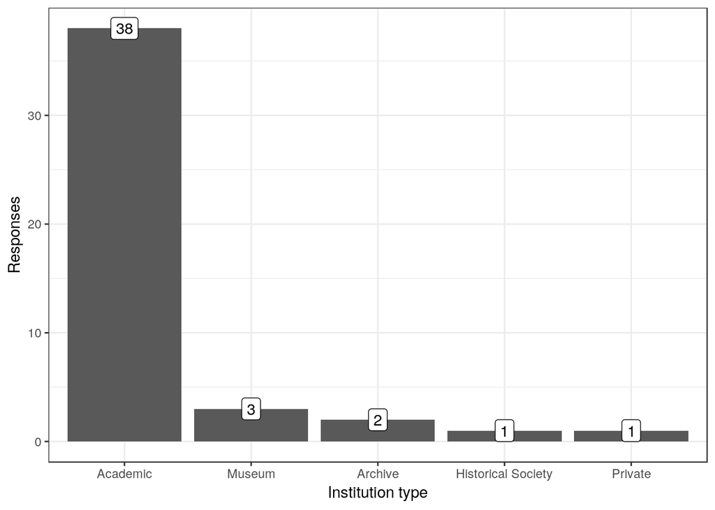

## Archivist skill self-evaluation ranges widely

We expected to find that most archivists were above average, on average, but believe that the distribution of self-assessment reflects a healthy self-criticism in the field.

Future work with surveys or interviews may find it useful to probe where archivists feel their skills are falling short.

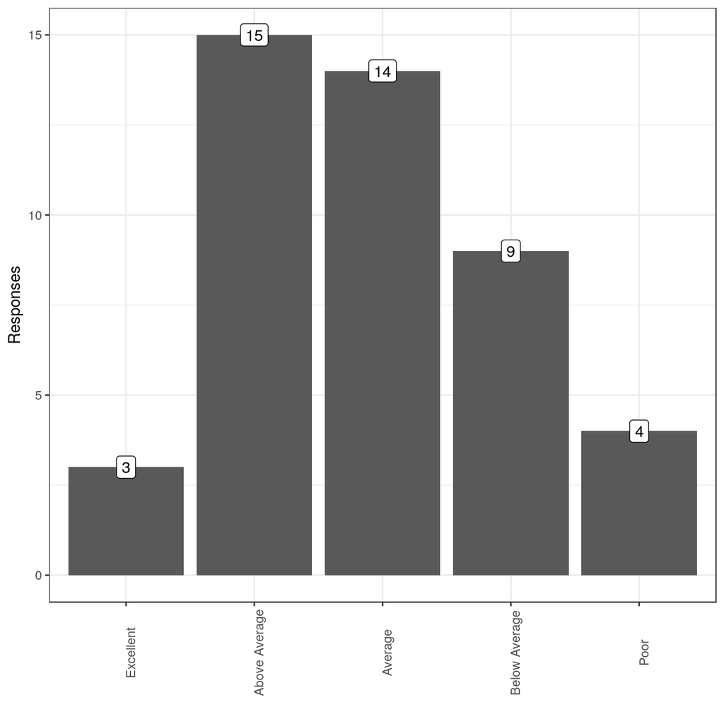

Self-assessment of skill might reflect how the archivist perceives the institution type, and so we compared self-assessed skill against different types of respondents. Since very few respondents that were not from “Academic” institutions, no conclusive pattern emerges.

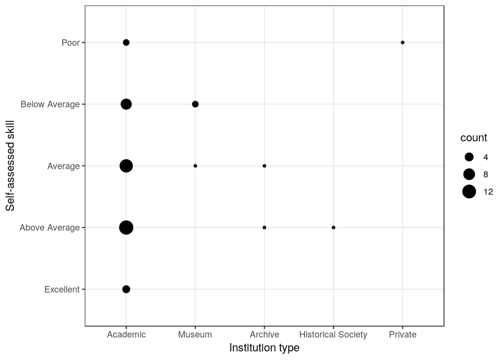

Self-assessment is unreliable without criteria. Developing a standardized set of practices around these media formats would help archivists self-identify shortcomings and correct it themselves, given adequate support from their institution.

## Respondents are geographically dispersed

We were satisfied to see that we were able to reach institutions across the United States, but we do see a high concentration in New York and Oregon.

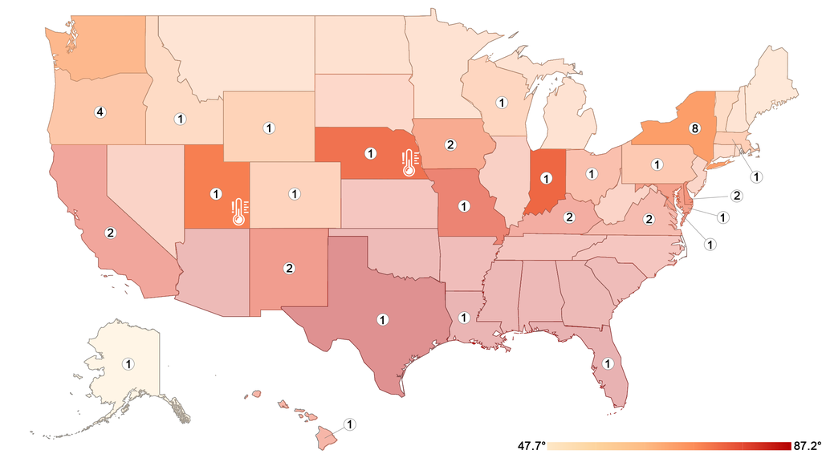

## Most but not all facilities store media in controlled conditions

We asked respondents to categorize their storage conditions for their collections. The different environmental archival levels are based on the Video Preservation Fact Sheet from AMIA. While the majority of the participants maintain “temperature/humidity controlled” storage, some respondents report “actively harmful” and “uncomfortable for humans” environments. `2` respondents didn’t include this information.

Tools like the AMIA Video Preservation Fact Sheet are important for sharing institutional knowledge across the broader community, and surveys like this can help disseminate these tools. We are optimistic that this dataset will allow archivists with poor-quality storage facilities to advocate for the support they need to bring their collection to meet the average practice.

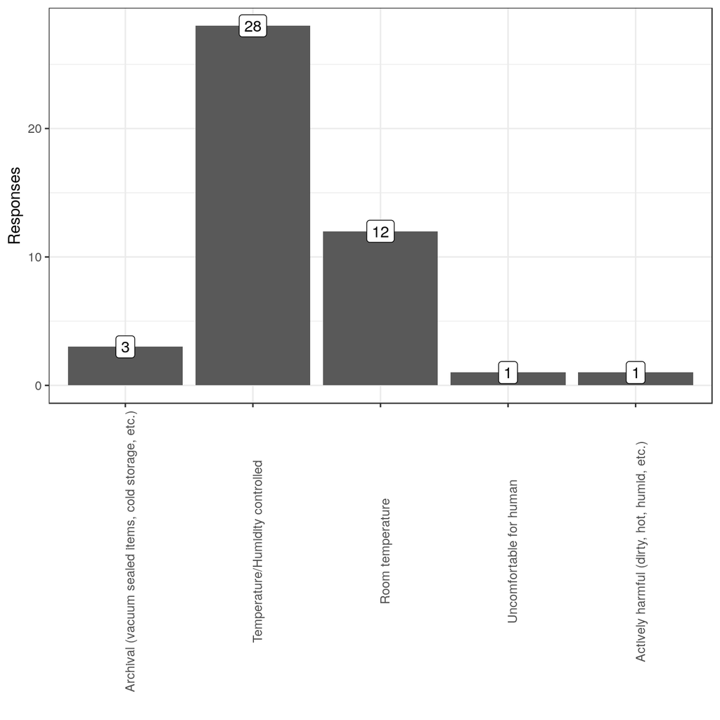

## Many items are estimated to decay before digitization

Of the `36` respondents who estimated how much magnetic material they would be able to digitize, eight—nearly a quarter—were confident they would process every item in their collection. However, almost as many institutions expressed doubt that they would digitize even a quarter of their collections before decay made their tapes unplayable. From a cursory examination, there does not appear to be a strict correlation between the size of the collection and the estimated digitization rate.

The bimodality may reflect a binary choice for the respondent, but it is striking that a significant fraction find themselves with little hope for preserving their collection.

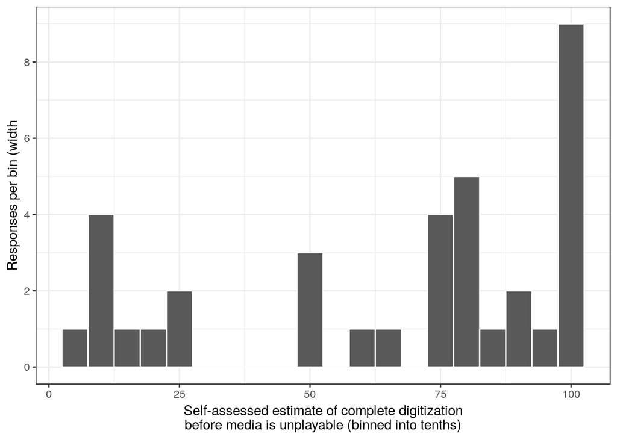

## There are not as many items left in formats at high-risk of decay

To prioritize digitization planning, we compared the sume total of items per format to each format’s obsolescence risk factor (CLIR, 1995). We found a relatively low number of high-risk formats, suggesting that niche high-risk formats may be preservable with focused efforts. It is worth noting that this pattern may reflect a survivor’s bias in collections.

Comparing the format’s risk of decay with the estimated total item count allows us to prioritize what formats to target immediately with focused grants.

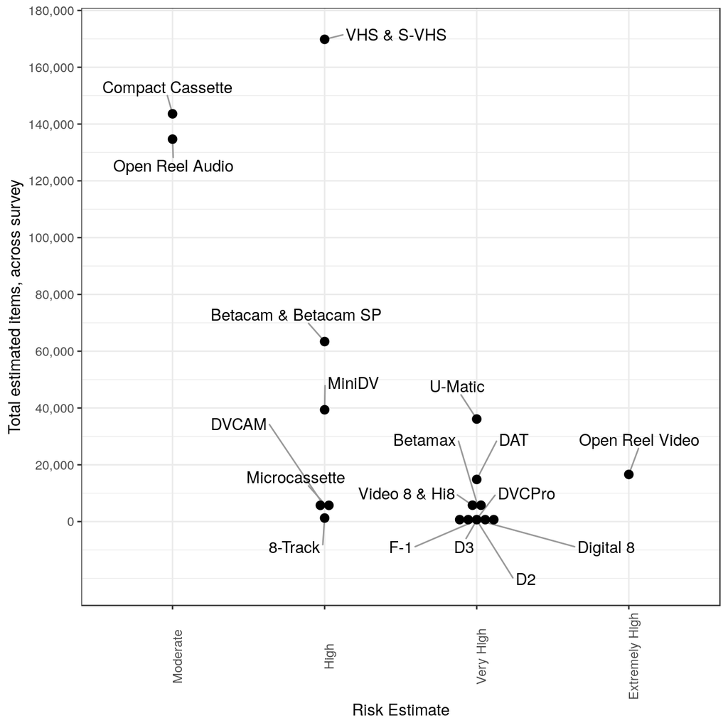

## Format abundances vary widely between institutions

Each y-axis is in log-scale, and so differences are exponential.

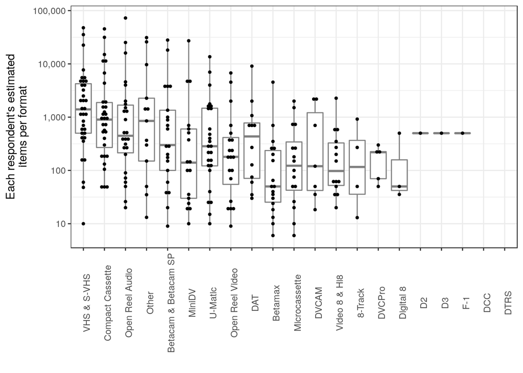

A similar pattern is seen in examining the proportion of each collection that is a format.

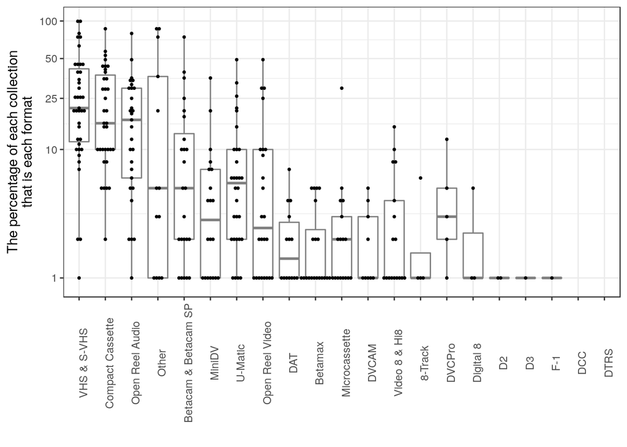

## Overall perspective on survey results

To summarize the collection compositions across institutions and formats, we display them as a heatmap below. The blue color key denotes the total estimated items of that format in that respondent’s collection, on a logarithmic scale (exponentially increasing). Format type is each column, labelled at the bottom. Each respondent is a row, with the estimated percentage of completion labelled.

Hierarchical clustering is a method to compare columns or rows to each other, such that adjacent rows are more similar than distant rows. When this is done, a tree is drawn along the side that is clustered, denoting how “related” the rows or columns are to each other.

The color scale at the top denotes the risk category.

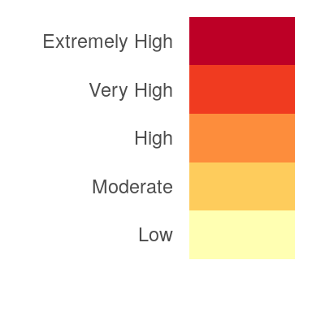

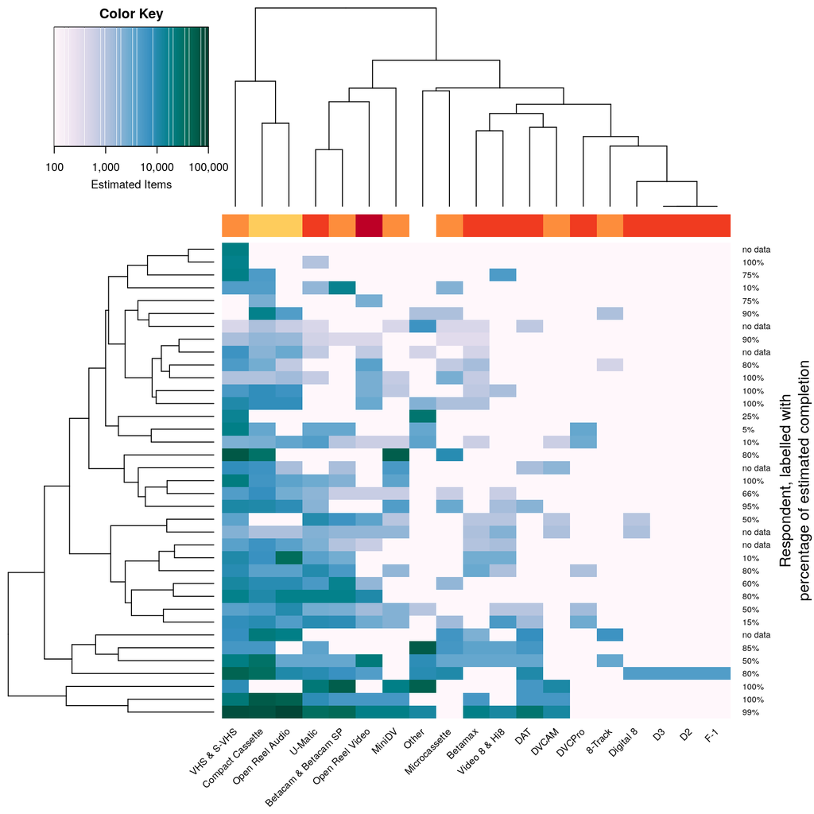

We qualitatively identify that VHS, open reel audio, and compact cassettes are one group of abundant and commonly held items, and appear to be the bulk of many collections. Similarly, U-Matic and Betacam formats are similar, and together with Open Reel Video and MiniDV form another cluster of somewhat common formats with less abundance but higher risk.

It appears that VHS, Compact Cassette, and Open Reel Audio are maybe the most commonly encountered cluster of formats. However, the higher risk Betacam and U-matic, and perhaps Open Reel Video with MiniDV, could be grouped for training, programming, and equipment in preserving these common but higher risk formats.

# Conclusions

While the data comes from a limited pool of academic archives and therefore cannot speak for all archives, the data can still serve to indicate what may be expected. Additional research addressing the preservation status of magnetic media collections in academic libraries, and to what degree are they endangered, could only make a stronger case for funding proposals. However, even without further research, it is imperative to report that archivists must begin by conducting assessments and evaluations of their collections in order to allocate resources to digitize their magnetic media collections. This is a crucial first step that needs to happen now, not later during the institution’s five-year plan. Moreover, this study illustrates that many institutions have not taken this first step.

# Acknowledgements

Many thanks to: our LIS 570 collaborators, Brian Click and Michael Kuster, who helped with the literature review, method design, and co-writing the original paper. Paul J. Weiss, LIS 570 instructor, who inspired and guided us to use this project to engage and contribute to the larger archives community. All survey respondents, interviewees, and archive listervs who welcomed our research to the discussion forums. Thank you SAA for accepted our research to the graduate student poster presentation.

# Supplemental analyses

## Do different institutions have patterns of collection composition?

Looking between institutions, how are collections composed? Are there major patterns of the differences between institutions?

We can use principal components analysis to pull out the major ways in which formats are distributed across institution. Principal components are ranked in order of their magnitude, so 1 explains the most variation while 2 explains the next most amount of variation. Counts were scaled and centered before being analyzed in this way.

Do institution types have different patterns of composition? In the two largest axes of variation, this is not apparent, but in axes 3 and 4 we see that museums and the only historical society are well seperated.

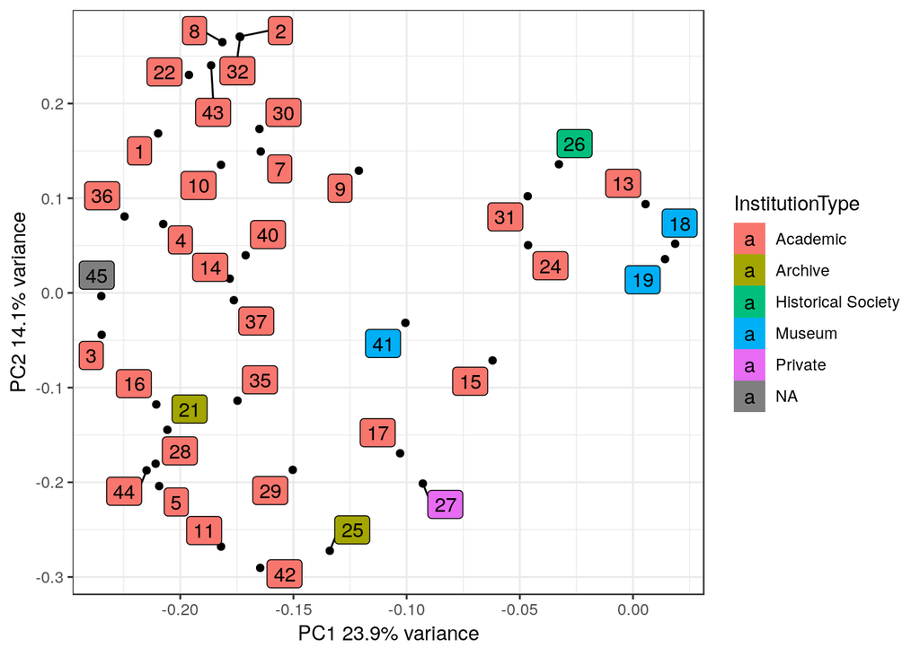

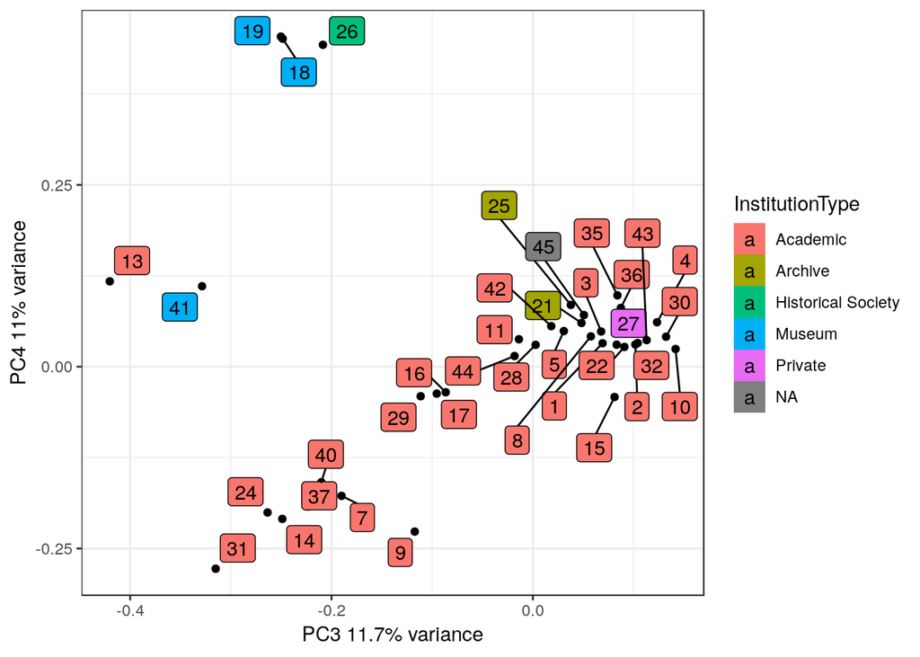

What differences in formats underlie these patters? Why are museums different than academic archives?

We correlated the counts of each format with the position on each axes of variation. Below these are plotted, and the labelled points are the correlations that were significantly correlated (spearman) by p < 0.05 with a bonferroni correction for six tests.

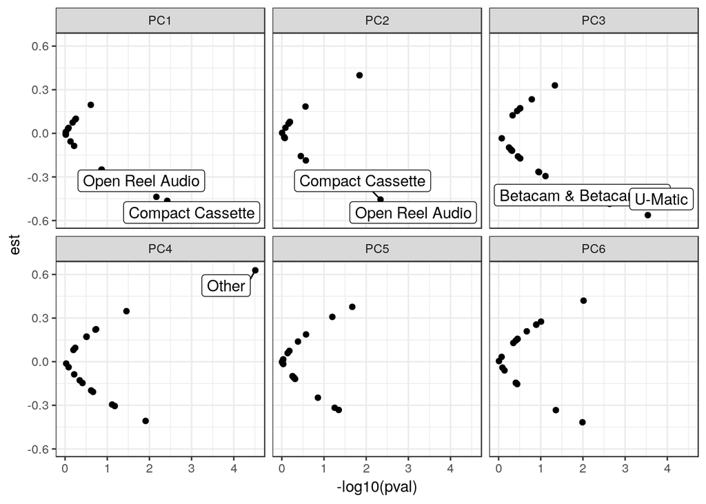

We see that Open Reel Audio and Compact Cassette are both well correlated with the two largest axes of variation, and may be indicative of large patterns of variation in collection formats

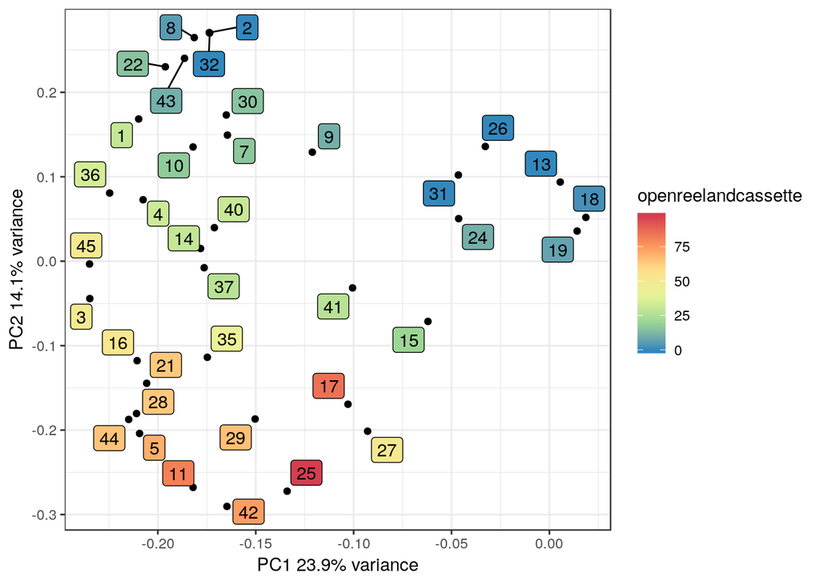

On the third and fourth largest axes of variation, we examine how Betacam, Umatic, and Other formats are distributed, and find that there are two clusters of large Betacam or Umatic collections amongst Academic institutions and that the museums and historical society have more Other format media (compare to plots above).

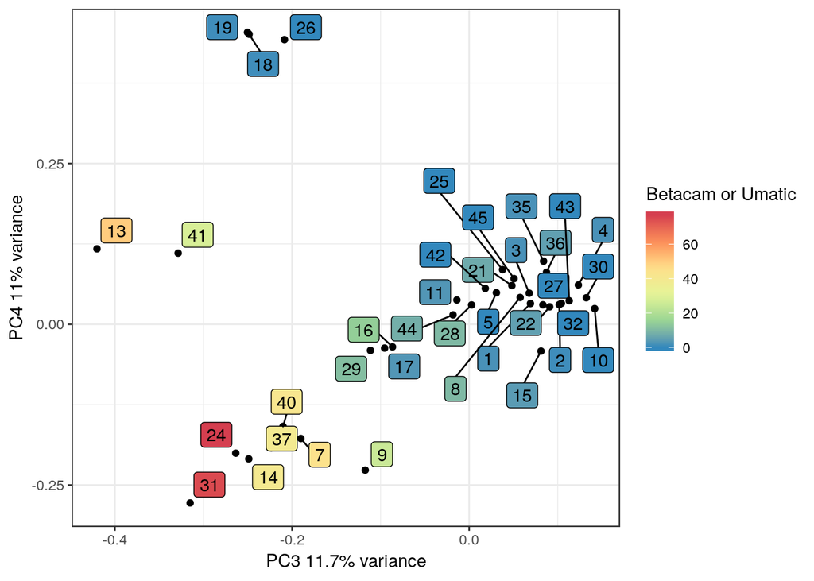

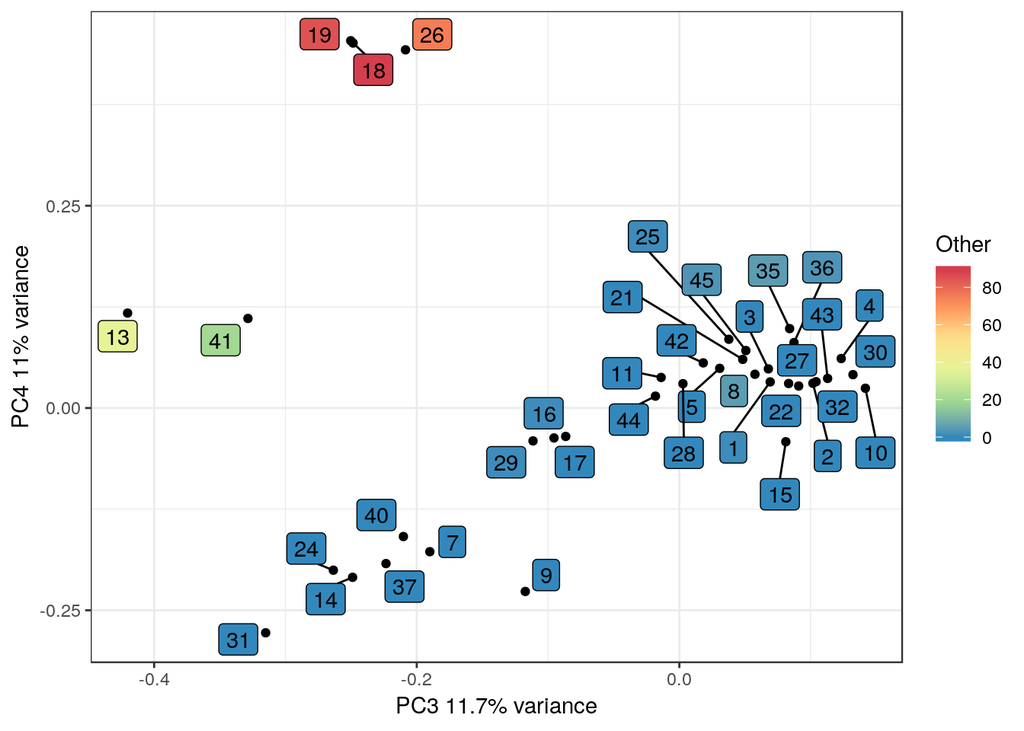

All together, this suggests that Betacam and Umatic are distinctly varying formats and so we may see heterogenity amongst institutions in holding these formats. The Other category distinguishes museums and the historical society that responded, suggesting that these institutions have distinct formats not addressed or categorized here.

[output not shown]

[output not shown]